# Stats2 Project 1

# Hitters Data Set

Source: https://www.kaggle.com/floser/hitters

The following text is verbatim from the website. It is mostly so I don’t have to go look at it constantly, we should delete or rephrase for the final submission.

This dataset is part of the R-package ISLR and is used in the related book by G. James et al. (2013) “An Introduction to Statistical Learning with applications in R” to demonstrate how Ridge regression and the LASSO are performed using R.

This dataset was originally taken from the StatLib library which is maintained at Carnegie Mellon University. This is part of the data that was used in the 1988 ASA Graphics Section Poster Session. The salary data were originally from Sports Illustrated, April 20, 1987. The 1986 and career statistics were obtained from The 1987 Baseball Encyclopedia Update published by Collier Books, Macmillan Publishing Company, New York.

Format A data frame with 322 observations of major league players on the following 20 variables. AtBat Number of times at bat in 1986 Hits Number of hits in 1986 HmRun Number of home runs in 1986 Runs Number of runs in 1986 RBI Number of runs batted in in 1986 Walks Number of walks in 1986 Years Number of years in the major leagues CAtBat Number of times at bat during his career CHits Number of hits during his career CHmRun Number of home runs during his career CRuns Number of runs during his career CRBI Number of runs batted in during his career CWalks Number of walks during his career League A factor with levels A and N indicating player’s league at the end of 1986 Division A factor with levels E and W indicating player’s division at the end of 1986 PutOuts Number of put outs in 1986 Assists Number of assists in 1986 Errors Number of errors in 1986 Salary 1987 annual salary on opening day in thousands of dollars NewLeague A factor with levels A and N indicating player’s league at the beginning of 1987

Please cite/acknowledge: Games, G., Witten, D., Hastie, T., and Tibshirani, R. (2013) An Introduction to Statistical Learning with applications in R, www.StatLearning.com, Springer-Verlag, New York.

## Dictionary

Again, not original content, this is from the website I am just making it more readable.

Format A data frame with 322 observations of major league players on the following 20 variables.  
AtBat Number of times at bat in 1986  
Hits Number of hits in 1986  
HmRun Number of home runs in 1986  
Runs Number of runs in 1986  
RBI Number of runs batted in in 1986  
Walks Number of walks in 1986  
Years Number of years in the major leagues  
CAtBat Number of times at bat during his career  
CHits Number of hits during his career  
CHmRun Number of home runs during his career  
CRuns Number of runs during his career  
CRBI Number of runs batted in during his career  
CWalks Number of walks during his career  
League A factor with levels A and N indicating player’s league at the end of 1986  
Division A factor with levels E and W indicating player’s division at the end of 1986  
PutOuts Number of put outs in 1986  
Assists Number of assists in 1986  
Errors Number of errors in 1986  
Salary 1987 annual salary on opening day in thousands of dollars  
NewLeague A factor with levels A and N indicating player’s league at the beginning of 1987

## Data Import

The data has 322 observations and 20 variables. 17 numeric variables and 3 character variables.

```r
hitters <- read_csv("Hitters.csv")
str(hitters)
```

```
Classes 'spec_tbl_df', 'tbl_df', 'tbl' and 'data.frame':    322 obs. of  20 variables:
 $ AtBat    : num  293 315 479 496 321 594 185 298 323 401 ...
 $ Hits     : num  66 81 130 141 87 169 37 73 81 92 ...
 $ HmRun    : num  1 7 18 20 10 4 1 0 6 17 ...
 $ Runs     : num  30 24 66 65 39 74 23 24 26 49 ...
 $ RBI      : num  29 38 72 78 42 51 8 24 32 66 ...
 $ Walks    : num  14 39 76 37 30 35 21 7 8 65 ...
 $ Years    : num  1 14 3 11 2 11 2 3 2 13 ...
 $ CAtBat   : num  293 3449 1624 5628 396 ...
 $ CHits    : num  66 835 457 1575 101 ...
 $ CHmRun   : num  1 69 63 225 12 19 1 0 6 253 ...
 $ CRuns    : num  30 321 224 828 48 501 30 41 32 784 ...
 $ CRBI     : num  29 414 266 838 46 336 9 37 34 890 ...
 $ CWalks   : num  14 375 263 354 33 194 24 12 8 866 ...
 $ League   : chr  "A" "N" "A" "N" ...
 $ Division : chr  "E" "W" "W" "E" ...
 $ PutOuts  : num  446 632 880 200 805 282 76 121 143 0 ...
 $ Assists  : num  33 43 82 11 40 421 127 283 290 0 ...
 $ Errors   : num  20 10 14 3 4 25 7 9 19 0 ...
 $ Salary   : num  NA 475 480 500 91.5 750 70 100 75 1100 ...
 $ NewLeague: chr  "A" "N" "A" "N" ...
 - attr(*, "spec")=
  .. cols(
  ..   AtBat = col_double(),
  ..   Hits = col_double(),
  ..   HmRun = col_double(),
  ..   Runs = col_double(),
  ..   RBI = col_double(),
  ..   Walks = col_double(),
  ..   Years = col_double(),
  ..   CAtBat = col_double(),
  ..   CHits = col_double(),
  ..   CHmRun = col_double(),
  ..   CRuns = col_double(),
  ..   CRBI = col_double(),
  ..   CWalks = col_double(),
  ..   League = col_character(),
  ..   Division = col_character(),
  ..   PutOuts = col_double(),
  ..   Assists = col_double(),
  ..   Errors = col_double(),
  ..   Salary = col_double(),
  ..   NewLeague = col_character()
  .. )
```

```r
head(hitters)
```

```
# A tibble: 6 x 20
  AtBat  Hits HmRun  Runs   RBI Walks Years CAtBat CHits CHmRun CRuns  CRBI
  <dbl> <dbl> <dbl> <dbl> <dbl> <dbl> <dbl>  <dbl> <dbl>  <dbl> <dbl> <dbl>
1   293    66     1    30    29    14     1    293    66      1    30    29
2   315    81     7    24    38    39    14   3449   835     69   321   414
3   479   130    18    66    72    76     3   1624   457     63   224   266
4   496   141    20    65    78    37    11   5628  1575    225   828   838
5   321    87    10    39    42    30     2    396   101     12    48    46
6   594   169     4    74    51    35    11   4408  1133     19   501   336
# ... with 8 more variables: CWalks <dbl>, League <chr>, Division <chr>,
#   PutOuts <dbl>, Assists <dbl>, Errors <dbl>, Salary <dbl>,
#   NewLeague <chr>
```

## Check for missing data

Salary seems to be missing for 17ish percent of the data, all other fields are present. I should look at the data dictionary its strange that the dependent variable has that much missing here.

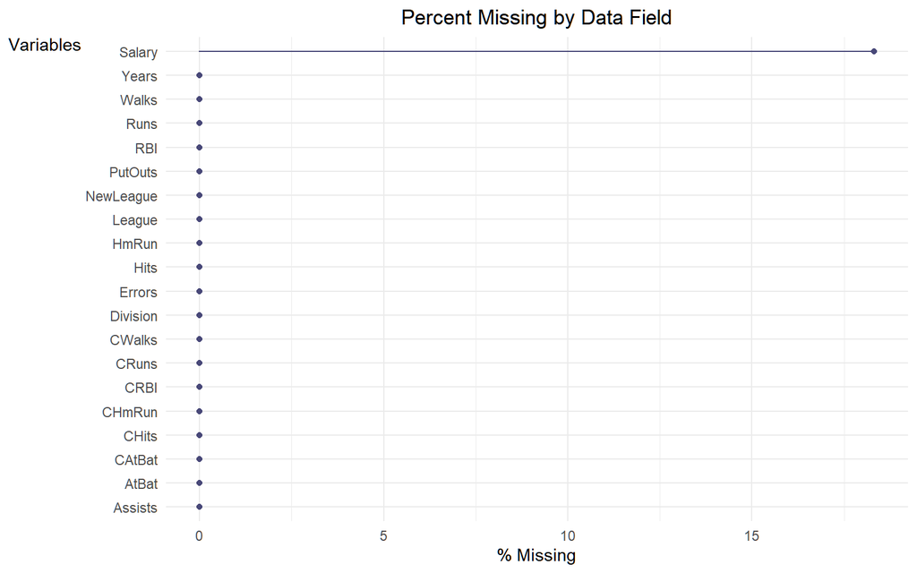

```r
library(naniar)
gg_miss_var(hitters, show_pct = TRUE) + labs(title = "Percent Missing by Data Field") +
    theme(legend.position = "none", plot.title = element_text(hjust = 0.5),
        axis.title.y = element_text(angle = 0, vjust = 1))
```

## Helper Functions

These are to just make EDA a little faster.

```r
barPlot <- function(df = hitters, x) {
    ggplot(df, aes_string(x = x)) + geom_bar()
}

propPlot <- function(df = hitters, x, y) {
    ggplot(df, aes_string(x = x, fill = y)) + geom_bar(position = "fill") +
        scale_y_continuous(labels = scales::percent)
}

fancyTable <- function(df = hitters, x) {
    df %>% group_by_at(x) %>% summarise(Count = n(), Proportion = scales::percent(n()/dim(df)[1])) %>%
        kable() %>% kable_styling(full_width = FALSE)
}

vioPlot <- function(df = hitters, x, y) {
    ggplot(df, aes_string(x = x, y = y, fill = x)) + geom_violin(show.legend = FALSE) +
        geom_boxplot(width = 0.2, show.legend = FALSE) + stat_summary(fun.y = mean,
        geom = "point", shape = 5, size = 4, color = "black", show.legend = FALSE)
}

histPlot <- function(df = hitters, x) {
    ggplot(df, aes_string(x)) + geom_histogram(bins = 30)
}

scatterPlot <- function(df = hitters, x, y = "Salary") {
    ggplot(df, aes_string(x = x, y = y)) + geom_point() + geom_smooth(method = "lm")
}
```

## Exploratory Data Analysis

### Pre-Processing

We can’t do any prediction on missing values. I am choosing to eliminate them now. A sub analyis would look at whether or not independent variables of missing observations have a different distribution.

```r
colsToFactor <- c("League", "Division", "NewLeague")
hitters[, colsToFactor] <- lapply(hitters[, colsToFactor], as.factor)
hitters <- hitters %>% filter(!is.na(Salary))
hitters$logSalary <- log(hitters$Salary)
```

### Salary

Salary is non-normal. May benefit from transformation. 59 NAs. Min Salary ~67.5K, not bad.

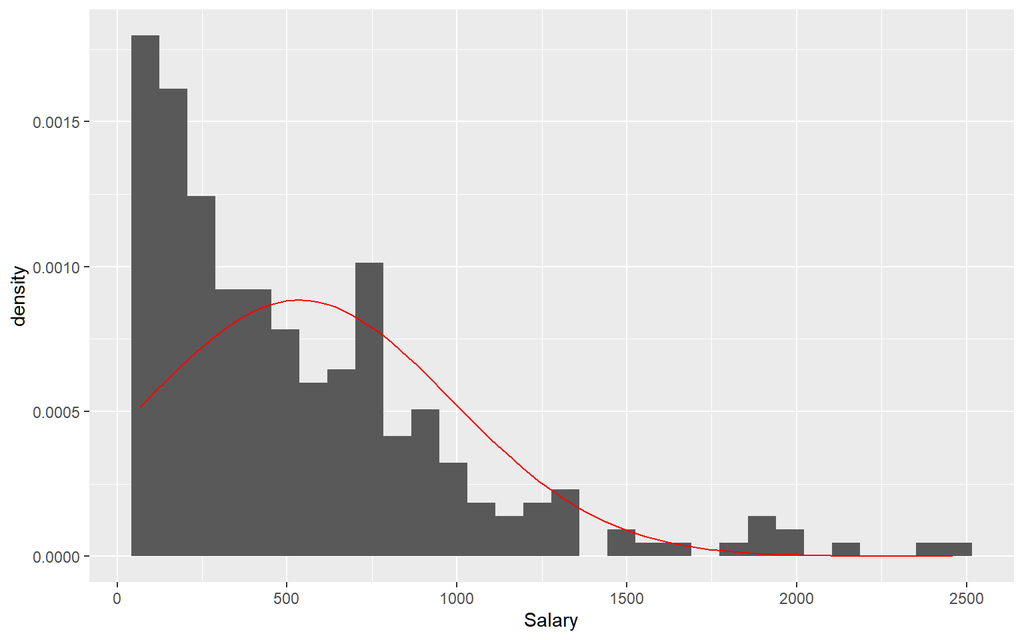

```r
ggplot(hitters, aes(Salary)) + geom_histogram(aes(y = ..density..), bins = 30) +
    stat_function(fun = dnorm, color = "red", args = list(mean = mean(hitters$Salary),
        sd = sd(hitters$Salary)))
```

```r
summary(hitters$Salary)
```

```
   Min. 1st Qu.  Median    Mean 3rd Qu.    Max.
   67.5   190.0   425.0   535.9   750.0  2460.0
```

### AtBat

Number of times at bat in 1986. Positive influence on Salary.

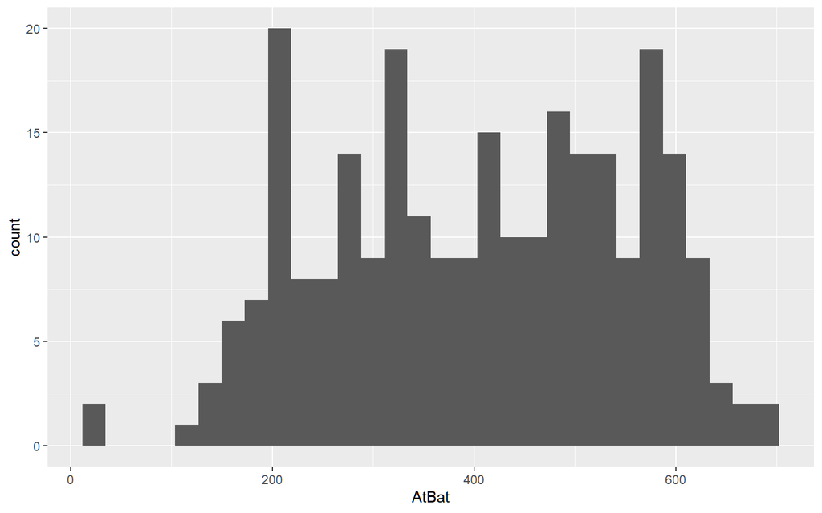

```r
histPlot(x = "AtBat")
```

```r
summary(hitters$AtBat)
```

```
   Min. 1st Qu.  Median    Mean 3rd Qu.    Max.
   19.0   282.5   413.0   403.6   526.0   687.0
```

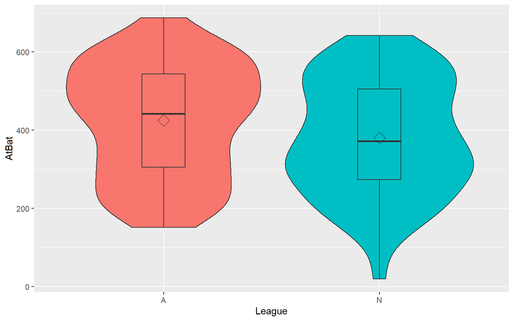

```r
vioPlot(x = "League", y = "AtBat")
```

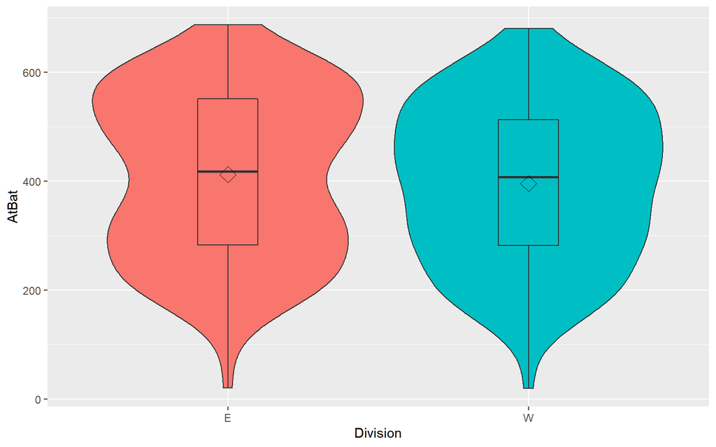

```r
vioPlot(x = "Division", y = "AtBat")
```

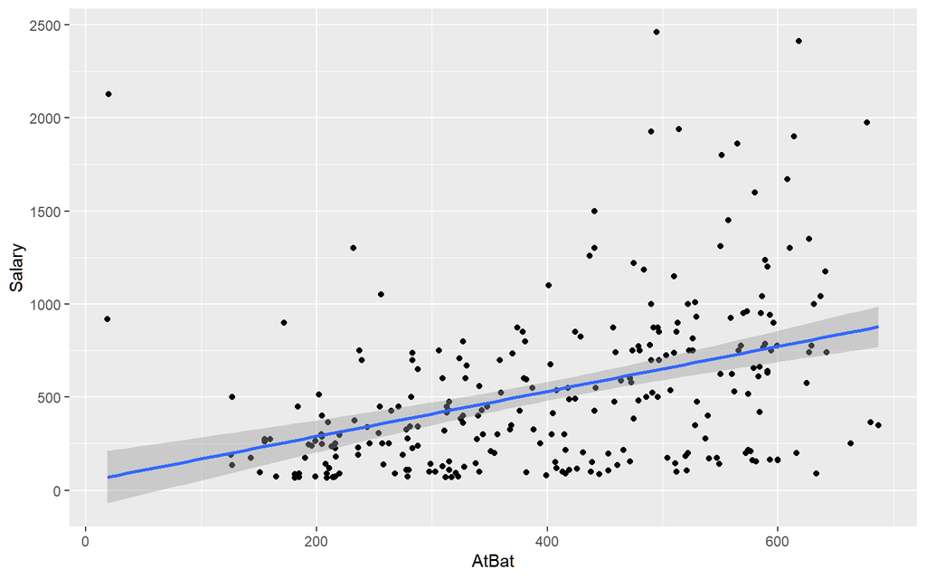

```r
scatterPlot(x = "AtBat")
```

### Hits

Hits Number of hits in 1986. Positive influence on Salary

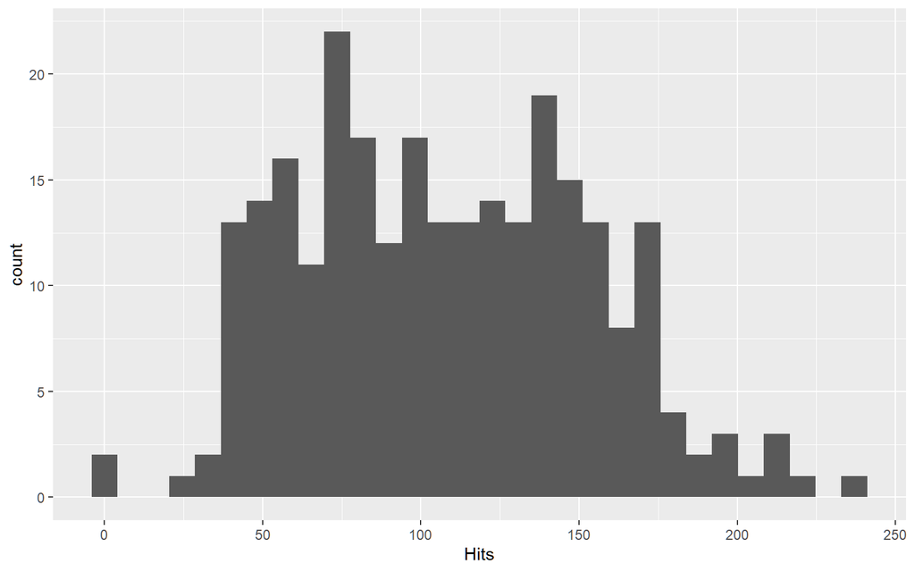

```r
histPlot(x = "Hits")
```

```r
summary(hitters$Hits)
```

```
   Min. 1st Qu.  Median    Mean 3rd Qu.    Max.
    1.0    71.5   103.0   107.8   141.5   238.0
```

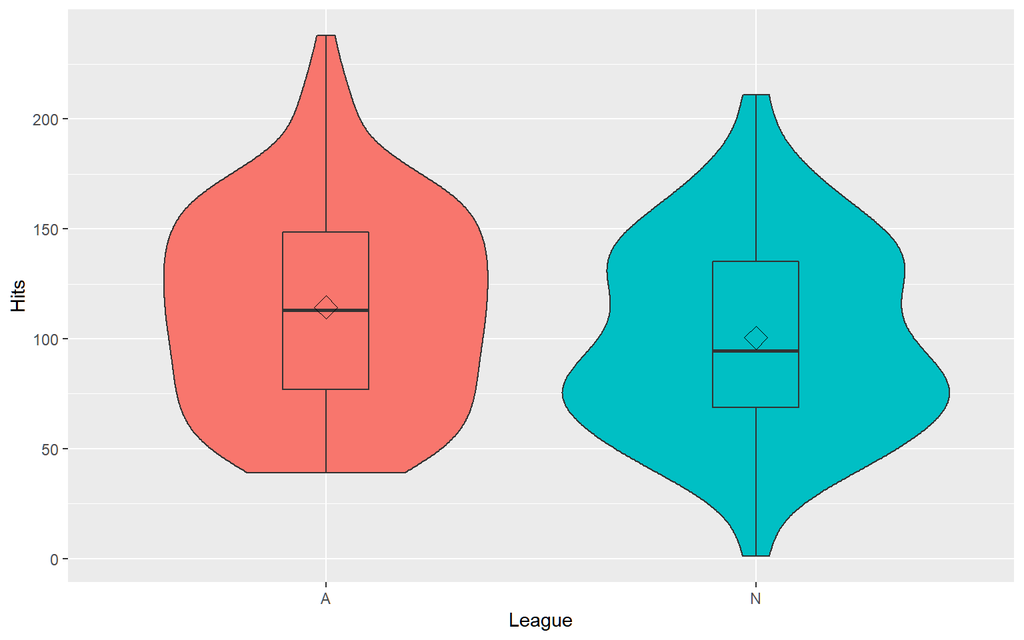

```r
vioPlot(x = "League", y = "Hits")
```

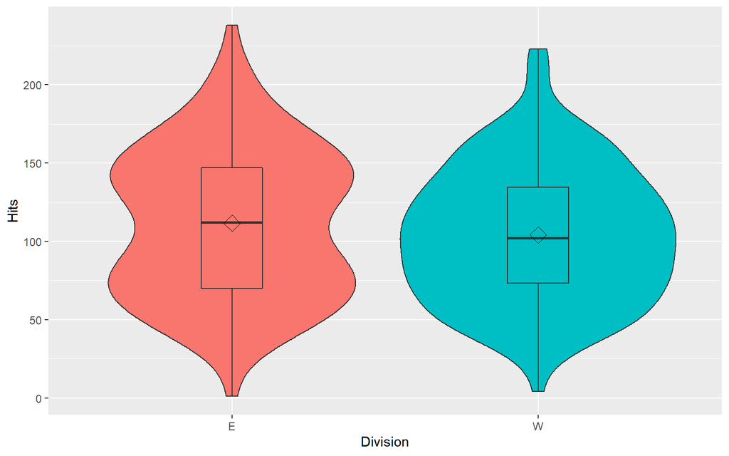

```r
vioPlot(x = "Division", y = "Hits")
```

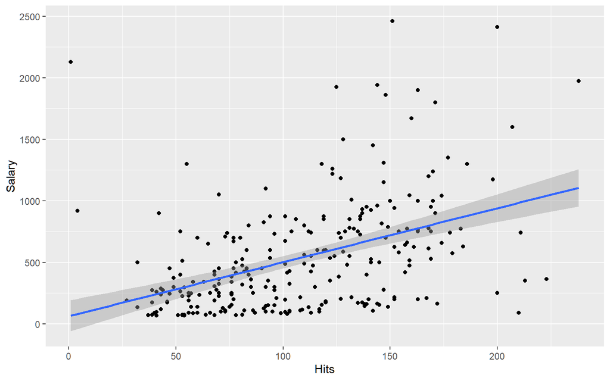

```r
scatterPlot(x = "Hits")
```

### HmRun

HmRun Number of home runs in 1986

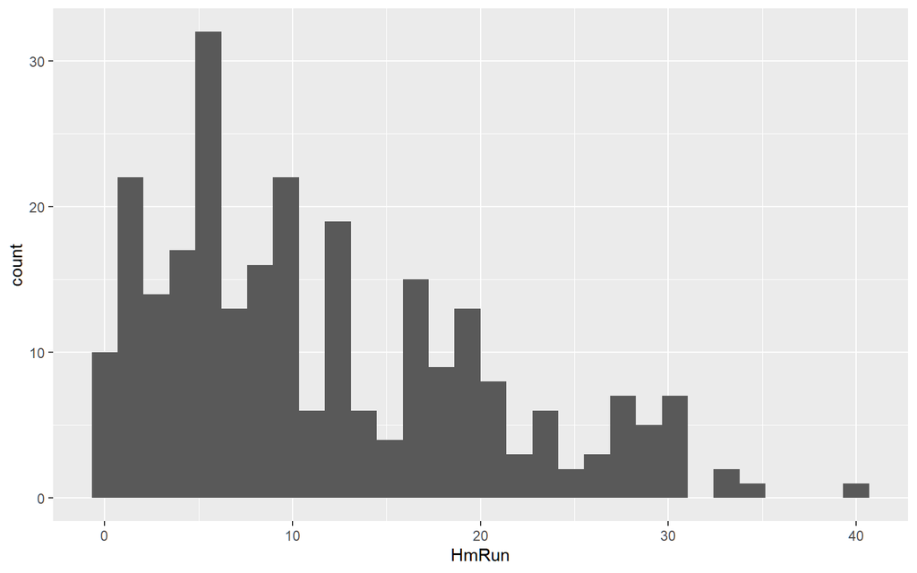

```r
histPlot(x = "HmRun")
```

```r
summary(hitters$HmRun)
```

```
   Min. 1st Qu.  Median    Mean 3rd Qu.    Max.
   0.00    5.00    9.00   11.62   18.00   40.00
```

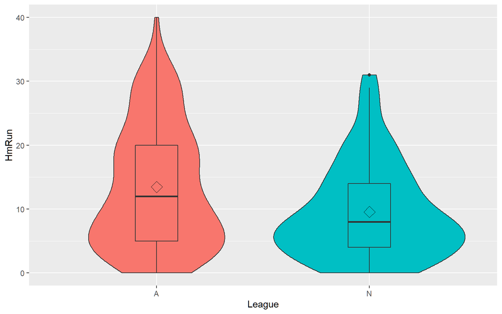

```r
vioPlot(x = "League", y = "HmRun")
```

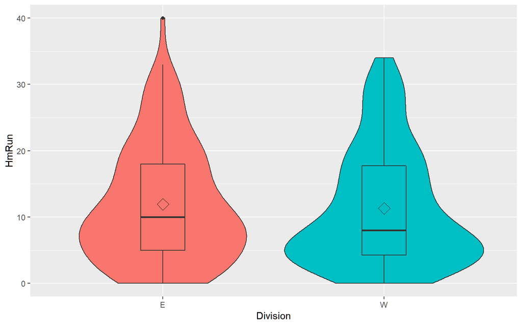

```r
vioPlot(x = "Division", y = "HmRun")
```

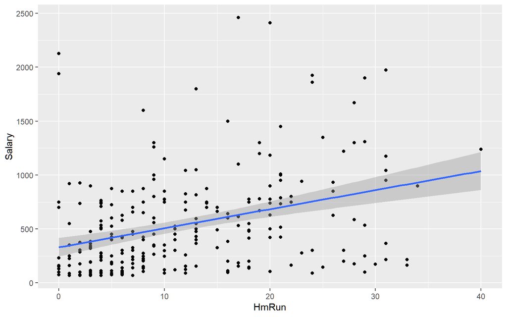

```r
scatterPlot(x = "HmRun")
```

### Runs

Runs Number of runs in 1986

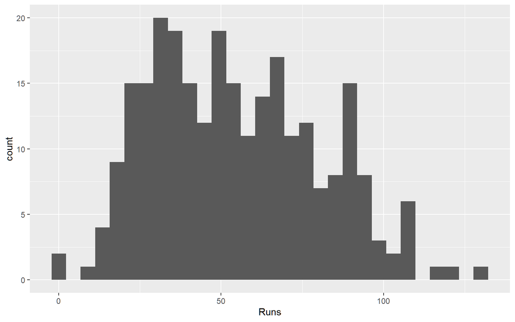

```r
histPlot(x = "Runs")
```

```r
summary(hitters$Runs)
```

```
   Min. 1st Qu.  Median    Mean 3rd Qu.    Max.
   0.00   33.50   52.00   54.75   73.00  130.00
```

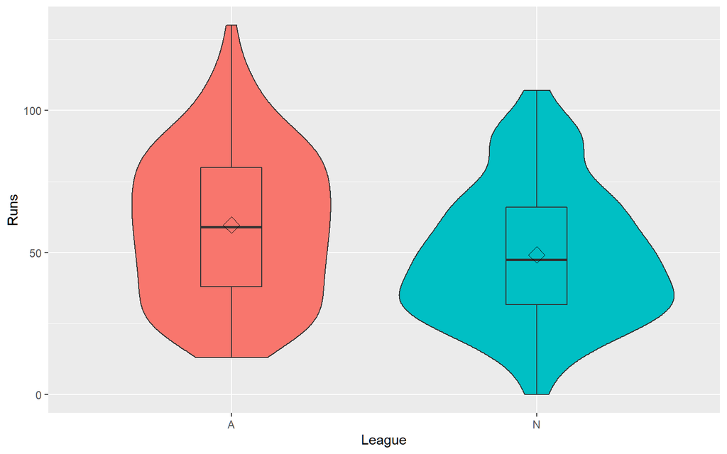

```r
vioPlot(x = "League", y = "Runs")
```

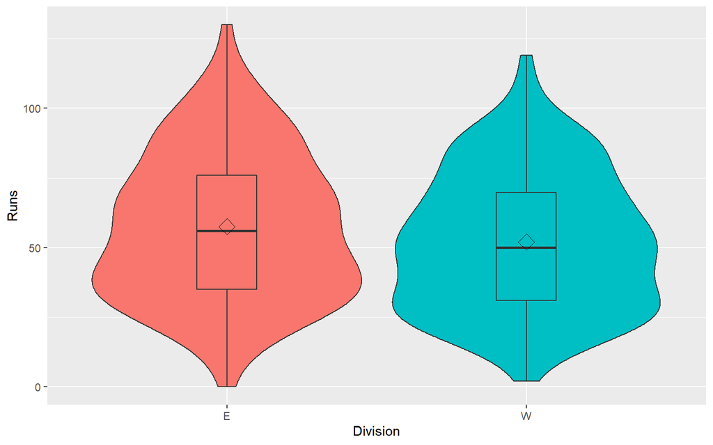

```r
vioPlot(x = "Division", y = "Runs")
```

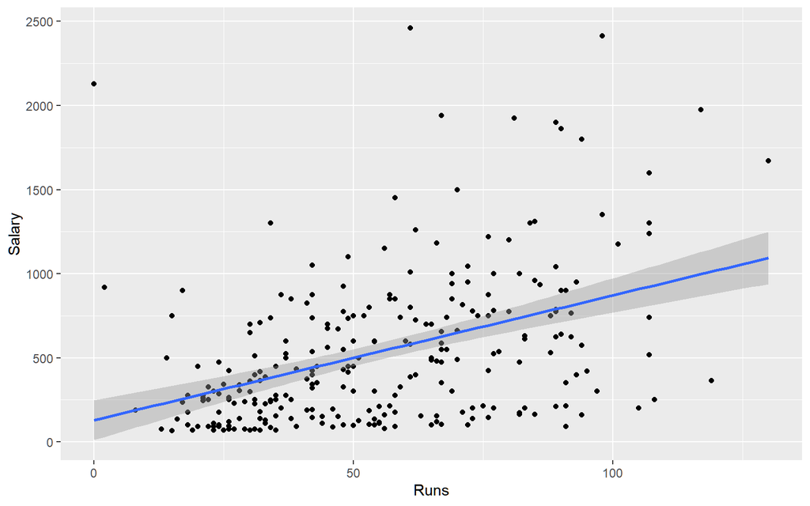

```r
scatterPlot(x = "Runs")
```

### RBI

RBI Number of runs batted in in 1986

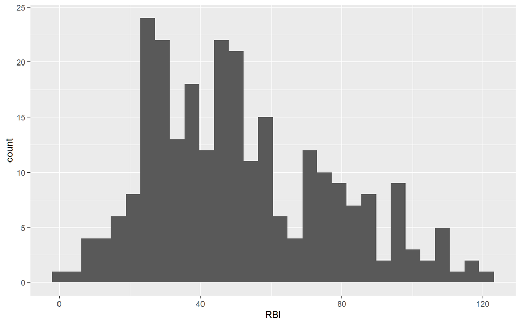

```r
histPlot(x = "RBI")
```

```r
summary(hitters$RBI)
```

```
   Min. 1st Qu.  Median    Mean 3rd Qu.    Max.
   0.00   30.00   47.00   51.49   71.00  121.00
```

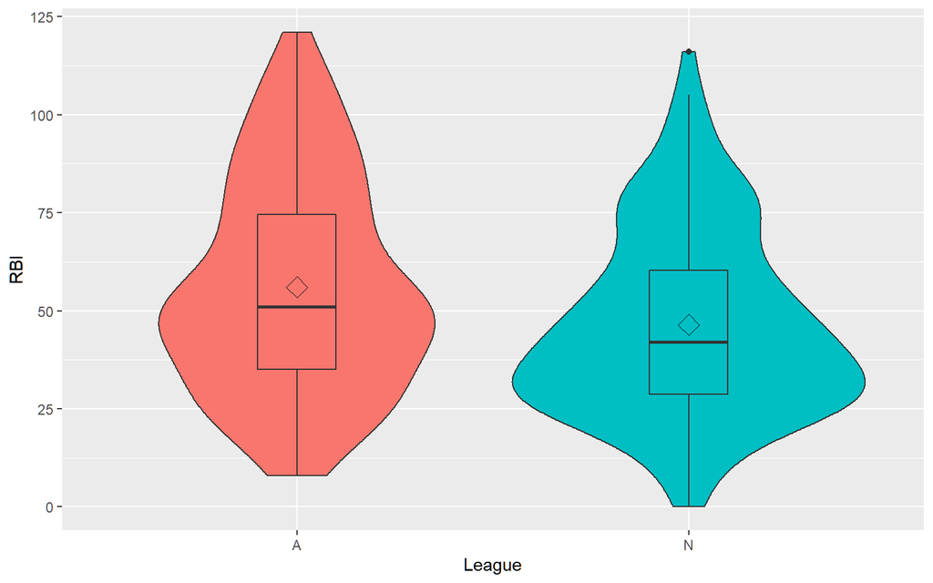

```r
vioPlot(x = "League", y = "RBI")
```

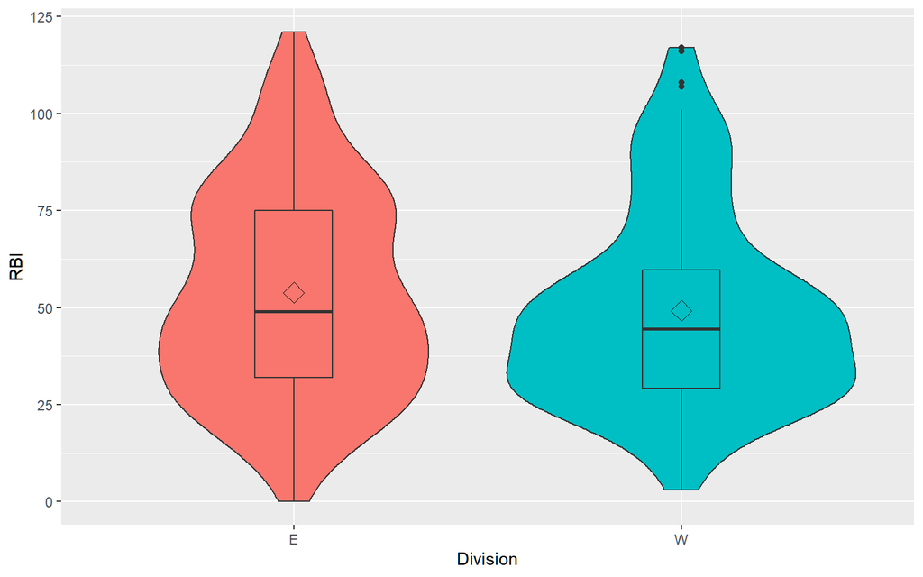

```r
vioPlot(x = "Division", y = "RBI")
```

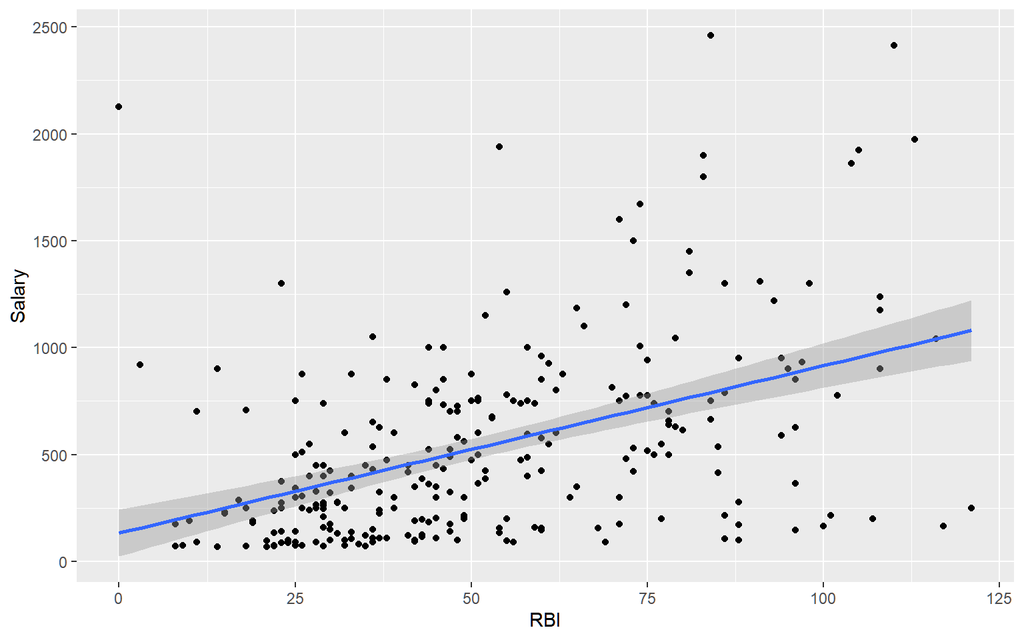

```r
scatterPlot(x = "RBI")
```

### Walks

Walks Number of walks in 1986

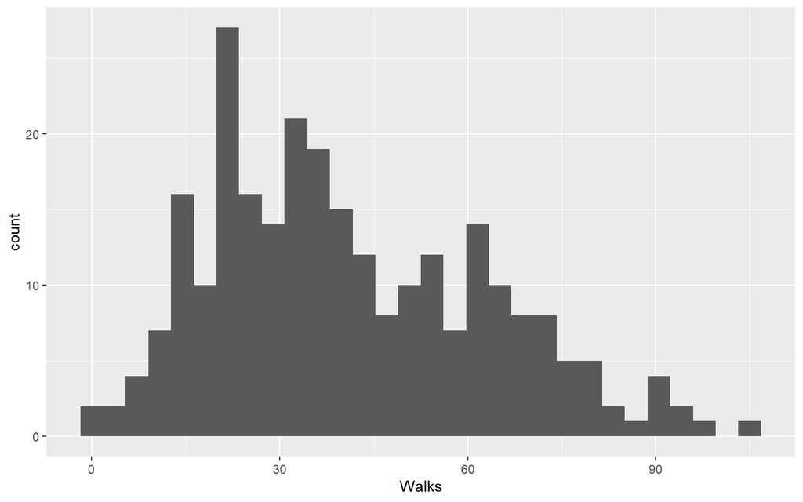

```r
histPlot(x = "Walks")
```

```r
summary(hitters$Walks)
```

```
   Min. 1st Qu.  Median    Mean 3rd Qu.    Max.
   0.00   23.00   37.00   41.11   57.00  105.00
```

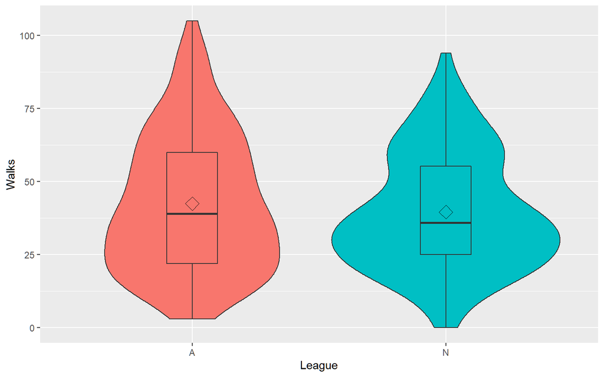

```r
vioPlot(x = "League", y = "Walks")
```

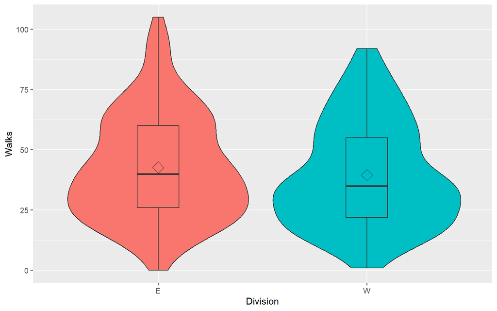

```r
vioPlot(x = "Division", y = "Walks")
```

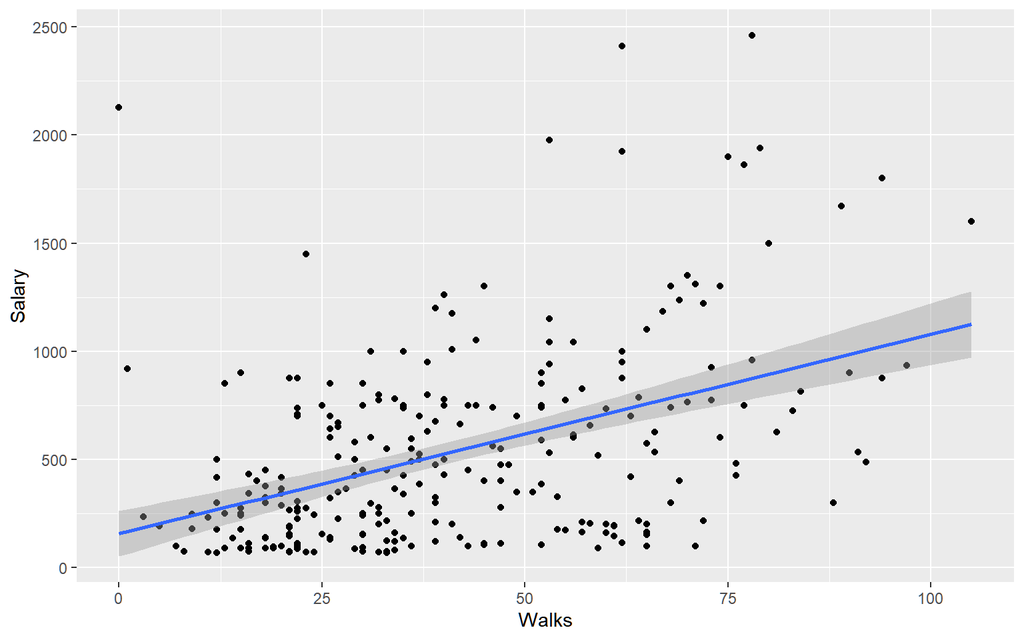

```r
scatterPlot(x = "Walks")
```

### Years

Years Number of years in the major leagues

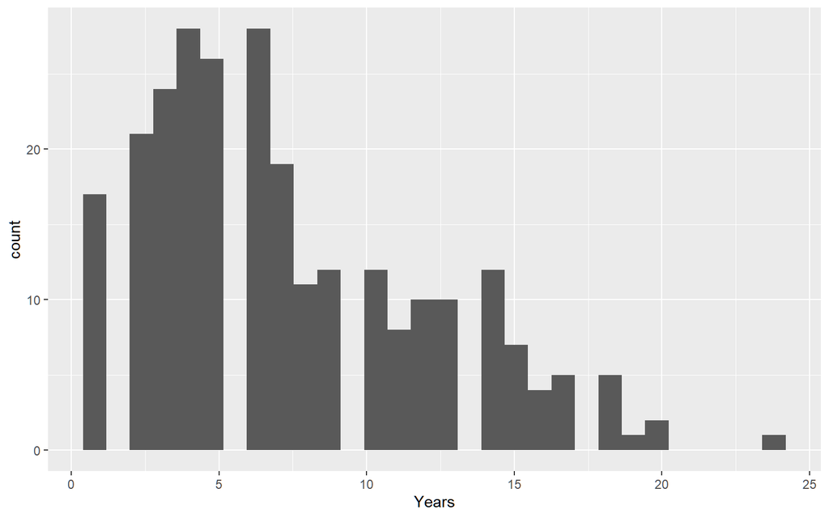

```r
histPlot(x = "Years")
```

```r
summary(hitters$Years)
```

```
   Min. 1st Qu.  Median    Mean 3rd Qu.    Max.
  1.000   4.000   6.000   7.312  10.000  24.000
```

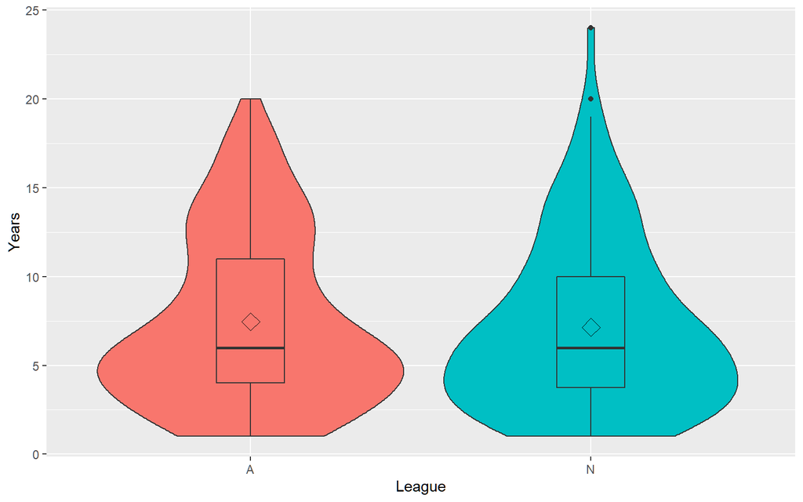

```r
vioPlot(x = "League", y = "Years")
```

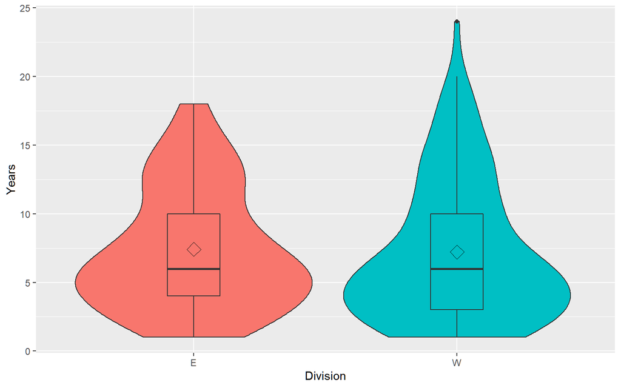

```r
vioPlot(x = "Division", y = "Years")
```

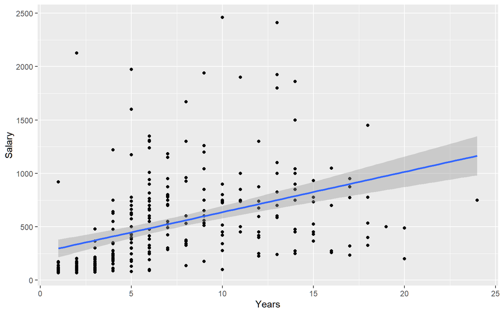

```r
scatterPlot(x = "Years")
```